# RAJKUMAR_sales_analysis

```python
#Import the required Libraries.
import numpy as np
import pandas as pd
import matplotlib.pyplot as plt

import seaborn as sns
```

## Data Cleaning

### Data Reading & Data Types

```python
#Read the data in pandas
inp0= pd.read_csv(r"C:\Users\User\Downloads\Data_Analysis_Project\Data_Analysis_Project\Attribute DataSet.csv")
inp1= pd.read_csv(r"C:\Users\User\Downloads\Data_Analysis_Project\Data_Analysis_Project\Dress Sales.csv ")
```

Ordinal Variable: The categories have a meaningful order or rank. Nominal Variable: The categories do not have a meaningful order or rank. price datatype iss Object type and categorical ordinal variable

You have “Attribute DataSet” which contains a column named “Price”. Choose the correct statement from the following about its data type and variable type. Integer type and numerical variable Object type and categorical ordinal variable Object type and categorical nominal variable Float type and categorical variable. ans:price datatype iss Object type and categorical ordinal variable

There is another column in “Attribute DataSet” named as “Recommendation”, choose the correct statement about its data type and variable type. Integer type and categorical Object type and categorical Integer type and continuous numerical Object type only. ans:Integer type and categorical

Which of the following column do you think are of no use in “Attribute DataSet”.

- Dress_ID
- Price
- Size and material -NeckLine -None of the above ans: none of the above

```python
# Print the information about the attributes of inp0 and inp1.
print(inp0.info())
print(inp1.info())
```

```
<class 'pandas.core.frame.DataFrame'>
RangeIndex: 479 entries, 0 to 478
Data columns (total 13 columns):
 #   Column          Non-Null Count  Dtype
---  ------          --------------  -----
 0   Dress_ID        479 non-null    int64
 1   Style           479 non-null    object
 2   Price           477 non-null    object
 3   Rating          479 non-null    float64
 4   Size            479 non-null    object
 5   Season          477 non-null    object
 6   NeckLine        476 non-null    object
 7   SleeveLength    477 non-null    object
 8   Material        360 non-null    object
 9   FabricType      223 non-null    object
 10  Decoration      255 non-null    object
 11  Pattern Type    377 non-null    object
 12  Recommendation  479 non-null    int64
dtypes: float64(1), int64(2), object(10)
memory usage: 48.8+ KB
None
<class 'pandas.core.frame.DataFrame'>
RangeIndex: 479 entries, 0 to 478
Data columns (total 24 columns):
 #   Column      Non-Null Count  Dtype
---  ------      --------------  -----
 0   Dress_ID    479 non-null    float64
 1   29-08-2013  479 non-null    int64
 2   31-08-2013  479 non-null    int64
 3   09-02-2013  479 non-null    int64
 4   09-04-2013  479 non-null    int64
 5   09-06-2013  479 non-null    int64
 6   09-08-2013  479 non-null    int64
 7   09-10-2013  479 non-null    int64
 8   09-12-2013  479 non-null    object
 9   14-09-2013  479 non-null    object
 10  16-09-2013  479 non-null    object
 11  18-09-2013  479 non-null    object
 12  20-09-2013  479 non-null    object
 13  22-09-2013  479 non-null    object
 14  24-09-2013  479 non-null    int64
 15  26-09-2013  257 non-null    float64
 16  28-09-2013  479 non-null    int64
 17  30-09-2013  222 non-null    float64
 18  10-02-2013  220 non-null    float64
 19  10-04-2013  221 non-null    float64
 20  10-06-2013  479 non-null    int64
 21  10-08-2013  224 non-null    float64
 22  10-10-2013  224 non-null    float64
 23  10-12-2013  479 non-null    int64
dtypes: float64(7), int64(11), object(6)
memory usage: 89.9+ KB
None
```

### Fixing the Rows and Columns

As you can see, there is a column in “Attribute Dataset” named as ‘Size’. This column contains the values in abbreviation format. Write a code in Python to convert the followings:

- M into “Medium”
- L into “Large”
- XL into “Extra large”
- free into “Free”
- S, s & small into “Small”.

Now once you are done with changes in the dataset, what is the value of the lowest percentage, the highest percentage and the percentage of Small size categories in the column named “Size”?

```python
# Column fixing, correcting size abbreviation. count the percentage of each size category in "Size" column.
size_mapping = {'M': 'Medium', 'L': 'Large', 'XL': 'Extra large', 'free': 'Free', 'S': 'Small','s': 'Small','small': 'Small'}
inp0['Size'].replace(size_mapping, inplace=True)
#size_counts = inp0['Size'].value_counts()
#Calculate the percentage of each size category
#size_percentage = (size_counts / size_counts.sum()) * 100
p=inp0.Size.value_counts()
q=p/p.sum() *100
```

```python
print(p)
print('-'*20)
print(q)
```

```
Size
Medium         171
Free           165
Large           93
Small           36
Extra large     14
Name: count, dtype: int64
--------------------
Size
Medium         35.699374
Free           34.446764
Large          19.415449
Small           7.515658
Extra large     2.922756
Name: count, dtype: float64
```

```python
inp0.head()
```

|  | Dress_ID | Style | Price | Rating | Size | Season | NeckLine | SleeveLength | Material | FabricType | Decoration | Pattern Type | Recommendation |
| --- | --- | --- | --- | --- | --- | --- | --- | --- | --- | --- | --- | --- | --- |
| 0 | 1006032852 | Sexy | Low | 4.6 | Medium | Summer | o-neck | sleevless | NaN | chiffon | ruffles | animal | 1 |
| 1 | 1212192089 | Casual | Low | 0.0 | Large | Summer | o-neck | Petal | microfiber | NaN | ruffles | animal | 0 |
| 2 | 1190380701 | vintage | High | 0.0 | Large | Automn | o-neck | full | polyster | NaN | NaN | print | 0 |
| 3 | 966005983 | Brief | Average | 4.6 | Large | Spring | o-neck | full | silk | chiffon | embroidary | print | 1 |
| 4 | 876339541 | cute | Low | 4.5 | Medium | Summer | o-neck | butterfly | chiffonfabric | chiffon | bow | dot | 0 |

### Impute/Remove Missing values

```python
# Print the null count of each variables of inp0 and inp1.
print(inp0.isnull().sum())
print('-'*20)
print(inp1.isnull().sum())
```

```
Dress_ID            0
Style               0
Price               2
Rating              0
Size                0
Season              2
NeckLine            3
SleeveLength        2
Material          119
FabricType        256
Decoration        224
Pattern Type      102
Recommendation      0
dtype: int64
--------------------
Dress_ID        0
29-08-2013      0
31-08-2013      0
09-02-2013      0
09-04-2013      0
09-06-2013      0
09-08-2013      0
09-10-2013      0
09-12-2013      0
14-09-2013      0
16-09-2013      0
18-09-2013      0
20-09-2013      0
22-09-2013      0
24-09-2013      0
26-09-2013    222
28-09-2013      0
30-09-2013    257
10-02-2013    259
10-04-2013    258
10-06-2013      0
10-08-2013    255
10-10-2013    255
10-12-2013      0
dtype: int64
```

You are given another dataset named “Dress Sales”. Now if you observe the datatypes of the columns using ‘inp1.info()’ command, you can identify that there are certain columns defined as object data type though they primarily consist of numeric data.

Now if you try and convert these object data type columns into numeric data type(float), you will come across an error message. Try to correct this error.

```python
inp1.info()
```

```
<class 'pandas.core.frame.DataFrame'>
RangeIndex: 479 entries, 0 to 478
Data columns (total 24 columns):
 #   Column      Non-Null Count  Dtype
---  ------      --------------  -----
 0   Dress_ID    479 non-null    float64
 1   29-08-2013  479 non-null    int64
 2   31-08-2013  479 non-null    int64
 3   09-02-2013  479 non-null    int64
 4   09-04-2013  479 non-null    int64
 5   09-06-2013  479 non-null    int64
 6   09-08-2013  479 non-null    int64
 7   09-10-2013  479 non-null    int64
 8   09-12-2013  479 non-null    object
 9   14-09-2013  479 non-null    object
```

[output cut: 16 more lines]

```python
# Try to convert the object type into float type of data. YOU GET ERROR MESSAGE.
inp1['09-12-2013'] = pd.to_numeric(inp1['09-12-2013'], errors='coerce')
inp1['14-09-2013'] = pd.to_numeric(inp1['14-09-2013'], errors='coerce')
inp1['16-09-2013'] = pd.to_numeric(inp1['16-09-2013'], errors='coerce')
inp1['18-09-2013'] = pd.to_numeric(inp1['18-09-2013'], errors='coerce')
inp1['20-09-2013'] = pd.to_numeric(inp1['20-09-2013'], errors='coerce')
inp1['22-09-2013'] = pd.to_numeric(inp1['22-09-2013'], errors='coerce')
```

```python
# Print the data types information of inp1 i.e. "Dress Sales" data.
inp1.dtypes
```

```
Dress_ID      float64
29-08-2013      int64
31-08-2013      int64
09-02-2013      int64
09-04-2013      int64
09-06-2013      int64
09-08-2013      int64
09-10-2013      int64
09-12-2013    float64
14-09-2013    float64
16-09-2013    float64
18-09-2013    float64
20-09-2013    float64
22-09-2013    float64
24-09-2013      int64
26-09-2013    float64
28-09-2013      int64
30-09-2013    float64
10-02-2013    float64
10-04-2013    float64
10-06-2013      int64
10-08-2013    float64
10-10-2013    float64
10-12-2013      int64
dtype: object
```

```python
# find string values in inp1
for col in inp1.columns:
    # Check if the column contains string values
    if inp1[col].dtype == 'object':
        # Find rows where the column contains the string 'a'
        filtered = inp1[inp1[col].str.contains('a', case=False, na=False)]
        # Append the filtered rows to the result DataFrame
        result = pd.concat([result, filtered])
```

```python
# Do the required changes in the "Dress Sales" data set to get null values on string values.
string_columns = inp1.select_dtypes(include=['object']).columns
inp1[string_columns] = inp1[string_columns].applymap(lambda x: np.nan if isinstance(x, str) else x)

# Display the DataFrame with null values in string columns
print("\nDress Sales DataFrame with null values in string columns:")
print(inp1)
```

```
Dress Sales DataFrame with null values in string columns:
         Dress_ID  29-08-2013  31-08-2013  09-02-2013  09-04-2013  09-06-2013  \
0    1.006033e+09        2114        2274        2491        2660        2727
1    1.212192e+09         151         275         570         750         813
2    1.190381e+09           6           7           7           7           8
3    9.660060e+08        1005        1128        1326        1455        1507
4    8.763395e+08         996        1175        1304        1396        1432
..            ...         ...         ...         ...         ...         ...
474  9.905592e+08           0           0           0          60          62
475  7.133920e+08           0           0           0         560         554
476  5.328743e+08           0           0           0         734         728
477  6.554649e+08           0           0           0         254         259
478  9.199310e+08           0           0           0         538         545

     09-08-2013  09-10-2013  09-12-2013  14-09-2013  ...  24-09-2013  \
```

[output cut: 39 more lines]

```python
# Convert the object type columns in "Dress Sales" into float type of data type.
inp1.info()
```

```
<class 'pandas.core.frame.DataFrame'>
RangeIndex: 479 entries, 0 to 478
Data columns (total 24 columns):
 #   Column      Non-Null Count  Dtype
---  ------      --------------  -----
 0   Dress_ID    479 non-null    float64
 1   29-08-2013  479 non-null    int64
 2   31-08-2013  479 non-null    int64
 3   09-02-2013  479 non-null    int64
 4   09-04-2013  479 non-null    int64
 5   09-06-2013  479 non-null    int64
 6   09-08-2013  479 non-null    int64
 7   09-10-2013  479 non-null    int64
 8   09-12-2013  478 non-null    float64
 9   14-09-2013  478 non-null    float64
```

[output cut: 16 more lines]

When you see the null counts in “Dress Sales” dataset after performing all the operations that have been mentioned in jupyter notebook, you will find that there are some columns in “Dress Sales” data where there are more than 40% of missing values. Based on your understanding of dealing with missing values do the following steps.

```python
# Print the null percetange of each column of inp1.
null_percentage = inp1.isnull().mean() * 100
print(null_percentage)
```

```
Dress_ID       0.000000
29-08-2013     0.000000
31-08-2013     0.000000
09-02-2013     0.000000
09-04-2013     0.000000
09-06-2013     0.000000
09-08-2013     0.000000
09-10-2013     0.000000
09-12-2013     0.208768
14-09-2013     0.208768
16-09-2013     0.208768
18-09-2013     0.208768
20-09-2013     0.208768
22-09-2013     0.208768
24-09-2013     0.000000
26-09-2013    46.346555
28-09-2013     0.000000
30-09-2013    53.653445
10-02-2013    54.070981
10-04-2013    53.862213
10-06-2013     0.000000
10-08-2013    53.235908
10-10-2013    53.235908
10-12-2013     0.000000
dtype: float64
```

```python
# Drop the columns in "Dress Sales" which have more than 40% of missing values.
threshold = 0.4  # Set the threshold for missing values
inp1= inp1.dropna(thresh=len(inp1) * (1 - threshold), axis=1)
print(inp1)
```

```
         Dress_ID  29-08-2013  31-08-2013  09-02-2013  09-04-2013  09-06-2013  \
0    1.006033e+09        2114        2274        2491        2660        2727
1    1.212192e+09         151         275         570         750         813
2    1.190381e+09           6           7           7           7           8
3    9.660060e+08        1005        1128        1326        1455        1507
4    8.763395e+08         996        1175        1304        1396        1432
..            ...         ...         ...         ...         ...         ...
474  9.905592e+08           0           0           0          60          62
475  7.133920e+08           0           0           0         560         554
476  5.328743e+08           0           0           0         734         728
477  6.554649e+08           0           0           0         254         259
478  9.199310e+08           0           0           0         538         545

     09-08-2013  09-10-2013  09-12-2013  14-09-2013  16-09-2013  18-09-2013  \
0          2887        2930      3119.0      3204.0      3277.0      3321.0
```

[output cut: 25 more lines]

```python
null_percentage = inp1.isnull().mean() * 100
print(null_percentage)
```

```
Dress_ID      0.000000
29-08-2013    0.000000
31-08-2013    0.000000
09-02-2013    0.000000
09-04-2013    0.000000
09-06-2013    0.000000
09-08-2013    0.000000
09-10-2013    0.000000
09-12-2013    0.208768
14-09-2013    0.208768
16-09-2013    0.208768
18-09-2013    0.208768
20-09-2013    0.208768
22-09-2013    0.208768
24-09-2013    0.000000
28-09-2013    0.000000
10-06-2013    0.000000
10-12-2013    0.000000
dtype: float64
```

You should categorise the dates into seasons in Dress Sales data to simplify the analysis according to the following criteria: June, July and August: Summer. September, October and November: Autumn. December, January and February: WInter. March, April and May: Spring

```python
# Create the four seasons columns in inp1, according to the above criteria.
inp1['Summer'] = inp1['09-06-2013'] + inp1['10-06-2013'] + inp1['29-08-2013'] + inp1['31-08-2013'] + inp1['09-08-2013']
inp1['Autumn'] = inp1['09-10-2013'] + inp1['14-09-2013'] + inp1['16-09-2013'] + inp1['18-09-2013'] + inp1['20-09-2013'] + inp1['22-09-2013'] + inp1['24-09-2013'] + inp1['28-09-2013']
inp1['Winter'] = inp1['09-12-2013'] + inp1['10-12-2013'] + inp1['09-02-2013']
inp1['Spring'] = inp1['09-04-2013']
print(inp1)
```

```
         Dress_ID  29-08-2013  31-08-2013  09-02-2013  09-04-2013  09-06-2013  \
0    1.006033e+09        2114        2274        2491        2660        2727
1    1.212192e+09         151         275         570         750         813
2    1.190381e+09           6           7           7           7           8
3    9.660060e+08        1005        1128        1326        1455        1507
4    8.763395e+08         996        1175        1304        1396        1432
..            ...         ...         ...         ...         ...         ...
474  9.905592e+08           0           0           0          60          62
475  7.133920e+08           0           0           0         560         554
476  5.328743e+08           0           0           0         734         728
477  6.554649e+08           0           0           0         254         259
478  9.199310e+08           0           0           0         538         545

     09-08-2013  09-10-2013  09-12-2013  14-09-2013  ...  20-09-2013  \
0          2887        2930      3119.0      3204.0  ...      3386.0
```

[output cut: 38 more lines]

```python
# calculate the sum of sales in each seasons in inp1 i.e. "Dress Sales".
inp1[['Summer','Autumn','Winter','Spring']].sum()
```

```
Summer     691907.0
Autumn    1353543.0
Winter     473640.0
Spring     143600.0
dtype: float64
```

Now let's merge inp1 with inp0 with left join manner, so that the information of inp0 should remain intact.

```python
# Merge inp0 with inp1 into inp0. this is also called left merge.
s=inp0 = pd.merge(left=inp0,right=inp1, how='left', left_on='Dress_ID', right_on='Dress_ID')
s.head()
```

|  | Dress_ID | Style | Price | Rating | Size | Season | NeckLine | SleeveLength | Material | FabricType | ... | 20-09-2013 | 22-09-2013 | 24-09-2013 | 28-09-2013 | 10-06-2013 | 10-12-2013 | Summer | Autumn | Winter | Spring |
| --- | --- | --- | --- | --- | --- | --- | --- | --- | --- | --- | --- | --- | --- | --- | --- | --- | --- | --- | --- | --- | --- |
| 0 | 1006032852 | Sexy | Low | 4.6 | Medium | Summer | o-neck | sleevless | NaN | chiffon | ... | 3386.0 | 3479.0 | 3554 | 3706 | 3897 | 4048 | 13899 | 26857.0 | 9658.0 | 2660 |
| 1 | 1212192089 | Casual | Low | 0.0 | Large | Summer | o-neck | Petal | microfiber | NaN | ... | 2106.0 | 2454.0 | 2710 | 3258 | 3911 | 4277 | 6216 | 17311.0 | 6405.0 | 750 |
| 2 | 1190380701 | vintage | High | 0.0 | Large | Automn | o-neck | full | polyster | NaN | ... | 10.0 | 11.0 | 11 | 11 | 11 | 11 | 40 | 82.0 | 28.0 | 7 |
| 3 | 966005983 | Brief | Average | 4.6 | Large | Spring | o-neck | full | silk | chiffon | ... | 1812.0 | 1845.0 | 1878 | 1914 | 1952 | 1963 | 7213 | 14411.0 | 5012.0 | 1455 |
| 4 | 876339541 | cute | Low | 4.5 | Medium | Summer | o-neck | butterfly | chiffonfabric | chiffon | ... | 1824.0 | 1919.0 | 2032 | 2252 | 2544 | 2736 | 7706 | 14676.0 | 5678.0 | 1396 |

5 rows × 34 columns

```python
# Now Drop the Date columns from inp0 as it is already combined into four seasons.
s=s.drop(columns=['09-06-2013', '10-06-2013', '29-08-2013', '31-08-2013', '09-08-2013', '09-10-2013',
                  '14-09-2013', '16-09-2013', '18-09-2013', '20-09-2013', '22-09-2013', '24-09-2013',
                  '28-09-2013', '09-12-2013', '10-12-2013', '09-02-2013', '09-04-2013'])

print(s)
```

```
       Dress_ID    Style    Price  Rating    Size  Season   NeckLine  \
0    1006032852     Sexy      Low     4.6  Medium  Summer     o-neck
1    1212192089   Casual      Low     0.0   Large  Summer     o-neck
2    1190380701  vintage     High     0.0   Large  Automn     o-neck
3     966005983    Brief  Average     4.6   Large  Spring     o-neck
4     876339541     cute      Low     4.5  Medium  Summer     o-neck
..          ...      ...      ...     ...     ...     ...        ...
474   990559192    Brief  Average     4.7  Medium  winter     o-neck
475   713391965   Casual      Low     4.7  Medium  Spring     o-neck
476   532874347   Casual  Average     4.7  Medium  Summer     v-neck
477   655464934   Casual  Average     4.6   Large  winter  boat-neck
478   919930954   Casual      Low     4.4    Free  Summer     v-neck

    SleeveLength       Material  FabricType  Decoration Pattern Type  \
0      sleevless            NaN     chiffon     ruffles       animal
```

[output cut: 25 more lines]

Print the null count of inp0 to get the idea about the missing values in data set.

```python
# Print the null count of each columns in inp0 dataframe i.e. combined data frame of inp0 and inp1 without date columns.
s.isnull().sum()
```

```
Dress_ID            0
Style               0
Price               2
Rating              0
Size                0
Season              2
NeckLine            3
SleeveLength        2
Material          119
FabricType        256
Decoration        224
Pattern Type      102
Recommendation      0
Summer              0
Autumn              2
Winter              1
Spring              0
dtype: int64
```

You can see that there are two types of variables one with a large number of missing values and another is very less number of missing values. These two columns can be categorized as:

Type-1: Missing values are very less (around 2 or 3 missing values): Price, Season, NeckLine, SleeveLength, Winter and Autumn.

Type-2: Missing values are large in numbers (more than 15%): Material, FabricType, Decoration and Pattern Type.

```python
# Deal with the missing values of Type-1 columns: Price, Season, NeckLine, SleeveLength, Winter and Autumn.

#s['Autumn'].fillna(s['Autumn'].mode(), inplace=True)
#s.dropna(subset=['Autumn', 'Winter','SleeveLength','NeckLine','Season','Price'], inplace=True)

s.replace(to_replace=[None], value=np.nan, inplace=True)

# Drop rows with NaN values
s.dropna(subset=['Autumn', 'Winter','SleeveLength','NeckLine','Season','Price'],inplace=True)
s.isnull().sum()
```

```
Dress_ID            0
Style               0
Price               0
Rating              0
Size                0
Season              0
NeckLine            0
SleeveLength        0
Material          116
FabricType        250
Decoration        220
Pattern Type       98
Recommendation      0
Summer              0
Autumn              0
Winter              0
Spring              0
dtype: int64
```

```python
# Deal with the missing values for Type-2 columns: Material, FabricType, Decoration and Pattern Type.
#s['Material']=s['Material'].fillna(s['Material'].mode().iloc[0])
s.dropna(subset=['Material','FabricType','Decoration','Pattern Type'],inplace=True)
s.isnull().sum()
```

```
Dress_ID          0
Style             0
Price             0
Rating            0
Size              0
Season            0
NeckLine          0
SleeveLength      0
Material          0
FabricType        0
Decoration        0
Pattern Type      0
Recommendation    0
Summer            0
Autumn            0
Winter            0
Spring            0
dtype: int64
```

```python
s.head()
```

|  | Dress_ID | Style | Price | Rating | Size | Season | NeckLine | SleeveLength | Material | FabricType | Decoration | Pattern Type | Recommendation | Summer | Autumn | Winter | Spring |
| --- | --- | --- | --- | --- | --- | --- | --- | --- | --- | --- | --- | --- | --- | --- | --- | --- | --- |
| 3 | 966005983 | Brief | Average | 4.6 | Large | Spring | o-neck | full | silk | chiffon | embroidary | print | 1 | 7213 | 14411.0 | 5012.0 | 1455 |
| 4 | 876339541 | cute | Low | 4.5 | Medium | Summer | o-neck | butterfly | chiffonfabric | chiffon | bow | dot | 0 | 7706 | 14676.0 | 5678.0 | 1396 |
| 7 | 1113094204 | Flare | Average | 0.0 | Free | Spring | v-neck | short | cotton | broadcloth | beading | solid | 1 | 68 | 181.0 | 60.0 | 12 |
| 9 | 1117293701 | party | Average | 5.0 | Free | Summer | o-neck | full | polyster | broadcloth | lace | solid | 0 | 275 | 624.0 | 245.0 | 49 |
| 27 | 942808364 | cute | Low | 4.3 | Free | Automn | o-neck | sleevless | polyster | chiffon | sashes | striped | 0 | 2288 | 4073.0 | 1497.0 | 475 |

### Standardise value

In the given dataset, there are certain discrepancies with the categorical names such as irregular spellings. Choose the correct option of columns with irregular categories and update them.

- Season, NeckLine
- Price, Material
- fabricType, Decoration
- Season, SleeveLength

```python
#correcting the spellings.
s['Season'].unique()
s['Season'].replace(['Automn','winter'], ['Autumn','Winter'], inplace=True)
s['Season'].unique()
```

```
array(['Spring', 'Summer', 'Autumn', 'Winter'], dtype=object)
```

```python
#correcting the Spellings.
s['SleeveLength'].unique()
s['SleeveLength'].replace(['thressqatar'], ['threequarter'], inplace=True)
s['SleeveLength'].unique()
```

```
array(['full', 'butterfly', 'short', 'sleevless', 'halfsleeve',
       'threequarter'], dtype=object)
```

There is a column named ‘Style’ in ‘Attribute Dataset’ which consists of the different style categories of the women apparels. Certain categories whose total sale is less than 50000 across all the seasons is considered under one single category as ‘Others’.

Which of the following categories in ‘Style’ column can be grouped into ‘Others’ category? and perform the grouping operation in the notebook for further analysis.

- Flare, fashion
- Novelty, bohemian
- OL, fashion, work
- Novelty, fashion, Flare

```python
# Group "Style" categories into "Others" which have less than 50000 sales across all the seasons.
#s['total'] = s['Summer'] + s['Autumn'] + s['Winter'] + s['Spring']
s['total'] = s[['Summer', 'Autumn', 'Winter', 'Spring']].sum(axis=1)

# Calculate total sales for each style
style_sales = s.groupby('Style')['total'].sum()

# Identify styles with total sales less than 50000
styles_to_group = style_sales[style_sales < 50000].index.tolist()

# Replace those styles with 'Others' using boolean indexing
s.loc[s['Style'].isin(styles_to_group), 'Style'] = 'Others'

# Check the updated DataFrame
s['Style'].unique()
```

```
array(['Brief', 'cute', 'Others', 'Casual', 'Sexy'], dtype=object)
```

```python
# Calculate the percentage of each categories in the "Style" variable.
k=inp0.Style.value_counts()
l=k/k.sum()*100
print(l)
```

```
Style
Casual      45.720251
Sexy        13.778706
party       10.647182
cute         9.185804
vintage      5.219207
bohemian     4.801670
Brief        3.549061
work         3.549061
sexy         1.461378
Novelty      1.252610
Flare        0.417537
OL           0.208768
fashion      0.208768
Name: count, dtype: float64
```

What is the percentage of “cute” and “Others” category in “Style” column in “Attribute DataSet” respectively?

- 46%, 5%
- 9%, 2.1%
- 2.1%, 5%
- 13.8%, 9% answer: 9%,2.1%

Similarly Club Neckline, SLeeve length categories into "Others" which have less than 50000 sales across all the seasons.

```python
# Group "Neckline" categories into "Others" which have less than 50000 sales across all the seasons.
s['total'] = s[['Summer', 'Autumn', 'Winter', 'Spring']].sum(axis=1)

# Calculate total sales for each style
Neckline_sales = s.groupby('NeckLine')['total'].sum()

# Identify styles with total sales less than 50000
Neckline_to_group = Neckline_sales[Neckline_sales < 50000].index.tolist()

# Replace those styles with 'Others' using boolean indexing
s.loc[s['NeckLine'].isin(Neckline_to_group), 'NeckLine'] = 'Others'

# Check the updated DataFrame
s['NeckLine'].unique()
```

```
array(['o-neck', 'v-neck', 'ruffled', 'Others'], dtype=object)
```

```python
# Group "Sleeve length" categories into "Others" which have less than 50000 sales across all the seasons.
s['total'] = s[['Summer', 'Autumn', 'Winter', 'Spring']].sum(axis=1)

# Calculate total sales for each style
SleeveLength_sales = s.groupby('SleeveLength')['total'].sum()

# Identify styles with total sales less than 50000
SleeveLength_to_group = SleeveLength_sales[SleeveLength_sales < 50000].index.tolist()

# Replace those styles with 'Others' using boolean indexing
s.loc[s['SleeveLength'].isin(SleeveLength_to_group), 'SleeveLength'] = 'Others'

# Check the updated DataFrame
s['SleeveLength'].unique()
```

```
array(['full', 'Others', 'short', 'sleevless', 'halfsleeve'], dtype=object)
```

```python
# Group "material" categories into "Others" which have less than 25000 sales across all the seasons.
s['total'] = s[['Summer', 'Autumn', 'Winter', 'Spring']].sum(axis=1)

# Calculate total sales for each style
Material_sales = s.groupby('Material')['total'].sum()

# Identify styles with total sales less than 50000
Material_to_group =Material_sales[Material_sales < 50000].index.tolist()

# Replace those styles with 'Others' using boolean indexing
s.loc[s['Material'].isin(Material_to_group), 'Material'] = 'Others'

# Check the updated DataFrame
s['Material'].unique()
```

```
array(['silk', 'chiffonfabric', 'cotton', 'polyster', 'Others', 'rayon'],
      dtype=object)
```

```python
# Group "fabric type" categories into "Others" which have less than 25000 sales across all the seasons.
s['total'] = s[['Summer', 'Autumn', 'Winter', 'Spring']].sum(axis=1)

# Calculate total sales for each fabric type
FabricType_sales = s.groupby('FabricType')['total'].sum()

# Identify styles with total sales less than 50000
FabricType_to_group = FabricType_sales[FabricType_sales < 50000].index.tolist()

# Replace those styles with 'Others' using boolean indexing
s.loc[s['FabricType'].isin(FabricType_to_group), 'FabricType'] = 'Others'

# Check the updated DataFrame
s['FabricType'].unique()
```

```
array(['chiffon', 'broadcloth', 'Others'], dtype=object)
```

```python
s.info()
```

```
<class 'pandas.core.frame.DataFrame'>
Index: 100 entries, 3 to 478
Data columns (total 18 columns):
 #   Column          Non-Null Count  Dtype
---  ------          --------------  -----
 0   Dress_ID        100 non-null    int64
 1   Style           100 non-null    object
 2   Price           100 non-null    object
 3   Rating          100 non-null    float64
 4   Size            100 non-null    object
 5   Season          100 non-null    object
 6   NeckLine        100 non-null    object
 7   SleeveLength    100 non-null    object
 8   Material        100 non-null    object
 9   FabricType      100 non-null    object
 10  Decoration      100 non-null    object
 11  Pattern Type    100 non-null    object
 12  Recommendation  100 non-null    int64
 13  Summer          100 non-null    int64
 14  Autumn          100 non-null    float64
 15  Winter          100 non-null    float64
 16  Spring          100 non-null    int64
 17  total           100 non-null    float64
dtypes: float64(4), int64(4), object(10)
memory usage: 14.8+ KB
```

```python
# Group "patern type" categories into "Others" which have less than 25000 sales across all the seasons.
s['total'] = s[['Summer', 'Autumn', 'Winter', 'Spring']].sum(axis=1)

# Calculate total sales for each style
Type_sales = s.groupby('Pattern Type')['total'].sum()

# Identify styles with total sales less than 50000
Type_to_group = Type_sales[Type_sales < 50000].index.tolist()

# Replace those styles with 'Others' using boolean indexing
s.loc[s['Pattern Type'].isin(Type_to_group), 'Pattern Type'] = 'Others'

# Check the updated DataFrame
s['Pattern Type'].unique()
```

```
array(['print', 'dot', 'solid', 'Others'], dtype=object)
```

```python
# Group "decoration" categories into "Others" which have less than 25000 sales across all the seasons.
s['total'] = s[['Summer', 'Autumn', 'Winter', 'Spring']].sum(axis=1)

# Calculate total sales for each style
Decoration = s.groupby('Decoration')['total'].sum()

# Identify styles with total sales less than 50000
Decoration_group = Decoration[Decoration < 50000].index.tolist()

# Replace those styles with 'Others' using boolean indexing
s.loc[s['Decoration'].isin(Decoration_group), 'Decoration'] = 'Others'

# Check the updated DataFrame
s['Decoration'].unique()
```

```
array(['Others', 'bow', 'lace', 'sashes', 'ruffles', 'applique'],
      dtype=object)
```

### Caregorical Ordered Univariate Analysis

Which of the following is an unordered variable in “Attribute DataSet”.

- Style
- Price
- Season
- Size ans: style becase remaining all,are in order

# Numerical variable Univariate analysis:

What is the approximate difference between the maximum value and 75th percentile in “Autumn” column.

- Approx 54000
- Approx 55000
- Approx 52000
- Approx 50000 ans: approx 52000

```python
x = s['Autumn'].max() - s['Autumn'].quantile(0.75)
x
```

```
51625.0
```

```python
# Describe the numerical variale: "Autumn".
s['Autumn'].describe()
```

```
count      100.000000
mean      3728.040000
std       6823.095931
min          1.000000
25%        493.500000
50%       1561.500000
75%       3907.000000
max      55532.000000
Name: Autumn, dtype: float64
```

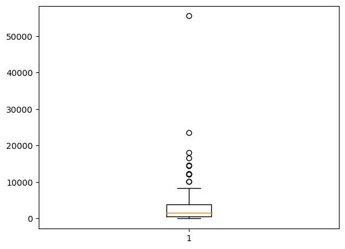

```python
# plot the boxplot of "Autumn" column.
plt.boxplot(s['Autumn'])
plt.show()
```

```python
# Find the maximum and 50th percentile of Winter season.
print(s['Winter'].max())
print(s['Winter'].quantile(0.50))
```

```
20388.0
439.0
```

```python
# Find the maximum and 50th percentile of Summer season.
print(s['Summer'].max())
print(s['Summer'].quantile(0.50))
```

```
35577
608.0
```

```python
# Find the maximum and 50th percentile of Spring season.
print(s['Spring'].max())
print(s['Spring'].quantile(0.50))
```

```
7374
129.5
```

```python
# Find the maximum and 50th percentile of Autumn season.
print(inp0['Autumn'].max())
print(inp0['Autumn'].quantile(0.50))
```

```
55532.0
1329.0
```